# Week 5: Data Wrangling

PM 566: Introduction to Health Data Science

George G. Vega Yon

## Today’s goals

We will learn about how to manipulate data, and in particular,

- Selecting variables.
- Filtering data.
- Creating variables.
- Summarize data.

Throughout the session we will see examples using:

- [**data.table**](https://cran.r-project.org/package=data.table) in R,
- [**dtplyr**](https://cran.r-project.org/package=dplyr) in R, and
- [**pydatatable**](https://github.com/h2oai/datatable)

All with the [MET](https://github.com/USCbiostats/data-science-data/) dataset.

## Data wrangling in R

Overall, you will find the following approaches:

- **base R**: Use only base R functions.
- **dplyr**: Using “verbs”.
- **data.table**: High-performing (ideal for large data)
- **dplyr + data.table = dtplyr**: High-performing + dplyr verbs.

Other methods involve, for example, using external tools such as [Spark](http://spark.apache.org/), [sparkly](https://cran.r-project.org/package=sparklyr).

We will be focusing on data.table because of [this](https://h2oai.github.io/db-benchmark/)

Take a look at this very neat cheat sheet by [Erik Petrovski](http://www.petrovski.dk/) [here](https://github.com/rstudio/cheatsheets/raw/master/datatable.pdf).

## Selecting variables: Load the packages

```r
library(data.table)
library(dtplyr)
library(dplyr)
```

The `dtplyr` R package translates `dplyr` (`tidyverse`) syntax to `data.table`, so that we can still use **the dplyr verbs** while at the same time leveraging the performance of `data.table`.

## Loading the data

The data that we will be using is an already processed version of the MET dataset. We can download (and load) the data directly in our session using the following commands:

```r
# Where are we getting the data from
met_url <- "https://github.com/USCbiostats/data-science-data/raw/master/02_met/met_all.gz"

# Downloading the data to a tempfile (so it is destroyed afterwards)
# you can replace this with, for example, your own data:
# tmp <- tempfile(fileext = ".gz")
tmp <- "met.gz"

# We sould be downloading this, ONLY IF this was not downloaded already.
# otherwise is just a waste of time.
if (!file.exists(tmp)) {
  download.file(
    url      = met_url,
    destfile = tmp,
    # method   = "libcurl", timeout = 1000 (you may need this option)
  )
}
```

Now we can load the data using the `fread()` function.

In R

```r
# Reading the data
dat <- fread(tmp)
head(dat)
```

In Python

```python
import datatable as dt
dat = dt.fread("met.gz")
dat.head(5)
```

Before we continue, let’s learn a bit more on `data.table` and `dtplyr`

## `data.table` and `dtplyr`:Data Table’s Syntax

- As you have seen in previous lectures, in `data.table` all happens within the square brackets. Here is common way to imagine DT:

[figure not shown]

- Any time that you see **:=** in **j** that is “Assignment by reference.” Using **=** within **j** only works in some specific cases.

## `data.table` and `dtplyr`:Data Table’s Syntax

- Operations applied in **j** are evaluated *within* the data, meaning that names work as symbols. e.g.

  ```r
  data(USArrests)
  USArrests_dt <- data.table(USArrests)

  # This returns an error
  USArrests[, Murder]

  # This works fine
  USArrests_dt[, Murder]
  ```

  Furthermore, we can do things like this:

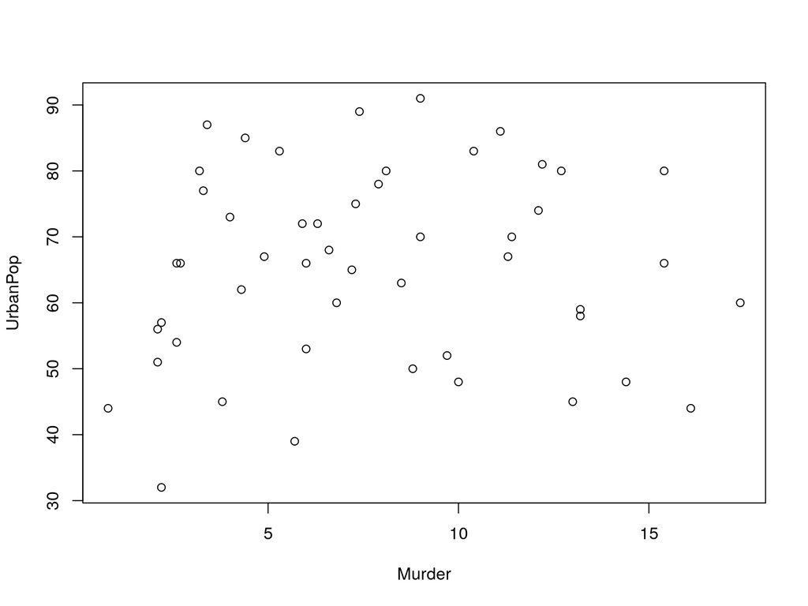

  ```r
  USArrests_dt[, plot(Murder, UrbanPop)]
  ```

## `data.table` and `dtplyr`: Lazy table

- The `dtplyr` package provides a way to translate `dplyr` verbs to `data.table` syntax.
- The key lies on the function `lazy_dt` from `dtplyr` (see `?dtplyr::lazy_dt`).
- This function creates a wrapper that “points” to a `data.table` object

## `data.table` and `dtplyr`: Lazy table (cont.)

```r
# Creating a lazy table object
dat_ldt <- lazy_dt(dat, immutable = FALSE)

# We can use the address() function from data.table
address(dat)
address(dat_ldt$parent)
```

```
## [1] "0x55df83eea180"
## [1] "0x55df83eea180"
```

[figure not shown]

Question: What is the `immutable = FALSE` option used for?

## Selecting columns

How can we select the columns `USAFID`, `lat`, and `lon`

```r
# data.table
dat[, list(USAFID, lat, lon)]

# dplyr verb
dat_ldt %>% select(USAFID, lat, lon)
```

In the case of `data.table`, What happens if instead of `list()` you used `c()`? Now, in Python

```python
dat[:,["USAFID", "lat", "lon"]]
```

What happens if instead of `["USAFID", "lat", "lon"]` you used `{"USAFID", "lat", "lon"}` (vector vs set).

## Data filtering: Logical conditions

- Based on logical operations, e.g. `condition 1 [and|or condition2 [and|or ...]]`
- Need to be aware of ordering and grouping of `and` and `or` operators.
- Fundamental **logical** operators:

  | x | y | Negate !x | And x & y | Or x \| y | Xor xor(x, y) |
  | --- | --- | --- | --- | --- | --- |
  | true | true | false | true | true | false |
  | false | true | true | false | true | true |
  | true | false | false | false | true | true |
  | false | false | true | false | false | false |

- Fundamental **relational** operators, in R: `<`, `>`, `<=`, `>=`, `==`, `!=`.

## Questions 1: How many ways can you write an XOR operator?

Write a function that takes two arguments `(x,y)` and applies the XOR operator element wise. Here you have a template:

```r
myxor <- function(x, y) {
  res <- logical(length(x))
  for (i in 1:length(x)) {
    res[i] <- # do something with x[i] and y[i]
  }
  return(res)
}
```

Or if vectorized (which would be better)

```r
myxor <- function(x, y) {
  # INSERT YOUR CODE HERE
}
```

Hint 1: Remember that negating `(x & y)` equals `(!x | !y)`.

Hint 2: Logical operators are a distributive, meaning `a * (b + c) = (a * b) + (a + c)`, where `*` and `+` are `&` or `|`.

In R

```r
myxor1 <- function(x,y) {(x & !y) | (!x & y)}
myxor2 <- function(x,y) {!((!x | y) & (x | !y))}
myxor3 <- function(x,y) {(x | y) & (!x | !y)}
myxor4 <- function(x,y) {!((!x & !y) | (x & y))}
cbind(
  ifelse(xor(test[,1], test[,2]), "true", "false"),
  ifelse(myxor1(test[,1], test[,2]), "true", "false"),
  ifelse(myxor2(test[,1], test[,2]), "true", "false"),
  ifelse(myxor3(test[,1], test[,2]), "true", "false"),
  ifelse(myxor4(test[,1], test[,2]), "true", "false")
)
```

```
##      [,1]    [,2]    [,3]    [,4]    [,5]
## [1,] "false" "false" "false" "false" "false"
## [2,] "true"  "true"  "true"  "true"  "true"
## [3,] "true"  "true"  "true"  "true"  "true"
## [4,] "false" "false" "false" "false" "false"
```

Or in python

```python
# Loading the libraries
import numpy as np
import pandas as pa

# Defining the data
x = [True, True, False, False]
y = [False, True, True, False]
ans = {
    'x'   : x,
    'y'   : y,
    'and' : np.logical_and(x, y),
    'or'  : np.logical_or(x, y),
    'xor' : np.logical_xor(x, y)
    }
pa.DataFrame(ans)
```

```
##        x      y    and     or    xor
## 0   True  False  False   True   True
## 1   True   True   True   True  False
## 2  False   True  False   True   True
## 3  False  False  False  False  False
```

Or in python (bis)

```python
def myxor(x,y):
    return np.logical_or(
        np.logical_and(x, np.logical_not(y)),
        np.logical_and(np.logical_not(x), y)
    )

ans['myxor'] = myxor(x,y)
pa.DataFrame(ans)
```

```
##        x      y    and     or    xor  myxor
## 0   True  False  False   True   True   True
## 1   True   True   True   True  False  False
## 2  False   True  False   True   True   True
## 3  False  False  False  False  False  False
```

We will now see applications using the `met` dataset

## Filtering (subsetting) the data

Need to select records according to some criteria. For example:

- First day of the month, and
- Above latitude 40, and
- Elevation outside the range 500 and 1,000.

In R with `data.table`

- `(day == 1)` First day of the month, and
- `(lat > 40)` Above latitude 40, and
- `((elev < 500) | (elev > 1000))` Elevation outside the range 500 and 1,000.

```r
dat[(day == 1) & (lat > 40) & ((elev < 500) | (elev > 1000))] %>%
  nrow()
```

In R with `dtplyr`

```r
dat_ldt %>%
  filter(day == 1, lat > 40, (elev < 500) | (elev > 1000)) %>%
  compute() %>% # Notice this line!
  nrow()
```

In Python

```python
import datatable as dt
dat = dt.fread("met.gz")
```

- `(dt.f.day == 1)` First day of the month, and
- `(dt.f.lat > 40)` Above latitude 40, and
- `((dt.f.elev < 500) | (dt.f.elev > 1000))` Elevation outside the range 500 and 1,000.

```python
dat[(dt.f.day == 1) & (dt.f.lat > 40) & ((dt.f.elev < 500) | (dt.f.elev > 1000)), :].nrows
# dat[dt.f.day == 1,:][dt.f.lat > 40,:][(dt.f.elev < 500) | (dt.f.elev > 1000),:].nrows
```

In the case of pydatatable we use `dt.f.` to refer to a column. `df.` is what we use to refer to datatable’s [namespace](https://en.wikipedia.org/wiki/Namespace).

The [`f.` is a symbol](https://datatable.readthedocs.io/en/latest/manual/f-expressions.html) that allows accessing column names in a datatable’s `Frame`.

## Questions 2

1. How many records have a temperature within 18 and 25?
2. Some records have missings. Count how many records have `temp` as `NA`?
3. Following the previous question, plot a sample of 1,000 of `(lat, lon)` of the stations with temp as NA and those with data.

## Solutions

```
## Question 1: 908047
```

```
## Question 2: 60089
```

```
## Question 3
```

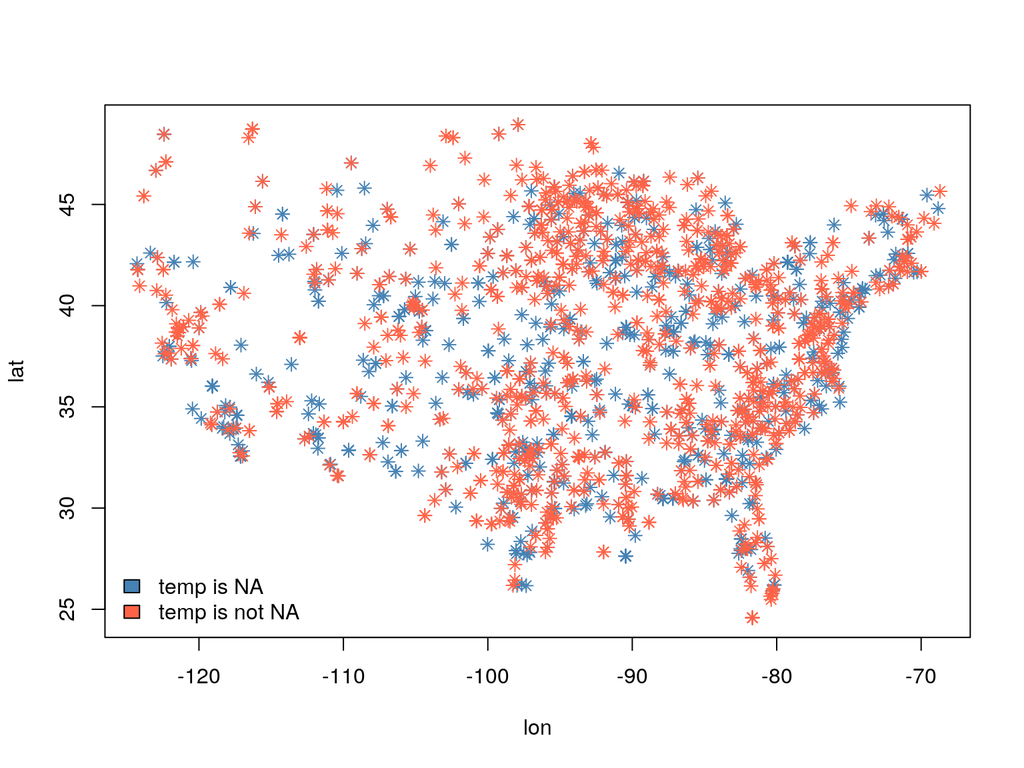

## Creating variables: Data types

- **logical**: Bool true/false type, e.g. dead/alive, sick/healthy, good/bad, yes/no, etc.
- **strings**: string of characters (letters/symbols), e.g. names, text, etc.
- **integer**: Numeric variable with no decimal (discrete), e.g. age, days, counts, etc.
- **double**: Numeric variable with decimals (continuous), e.g. distance, expression level, time.

## Creating variables: Special data types

Most programming languages have special types which are built using basic types. A few examples:

- **time**: Could be date, date + time, or a combination of both. Usually it has a reference number defined as date 0. In R, the `Date` class has as reference 1970-01-01, in other words, “days since January 1st, 1970”.
- **categorical**: Commonly used to represent strata/levels of variables, e.g. a variable “country” could be represented as a factor, where the data is stored as numbers but has a label.
- **ordinal**: Similar to factor, but it has ordering, e.g. “satisfaction level: 5 very satisfied, …, 1 very unsatisfied”.

Other special data types could be ways to represent missings (usually described as `na` or `NA`), or special numeric types, e.g. `+-Inf` and Undefined (`NaN`).

When storing/sharing datasets, it is a good practice to do it along a dictionary describing each column data type/format.

## Questions 3: What’s the best way to represent the following

- 0, 1, 1, 0, 0, 1
- Diabetes type 1, Diabetes type 2, Diabetes type 1, Diabetes type 2
- on, off, off, on, on, on
- 5, 10, 1, 15, 0, 0, 1
- 1.0, 2.0, 10.0, 6.0
- high, low, medium, medium, high
- -1, 1, -1, -1, 1,
- .2, 1.5, .8, $\pi$
- $\pi$, $\exp{1}$, $\pi$, $\pi$

## Variable creation

If we wanted to create two variables, `elev^2` and the scaled version of `wind.sp` by it’s standard error, we could do the following

With `data.table`

```r
dat[, elev2         := elev^2]
dat[, windsp_scaled := wind.sp/sd(wind.sp, na.rm = TRUE)]
# Alternatively:
# dat[, c("elev2", "windsp_scaled") := .(elev^2, wind.sp/sd(wind.sp,na.rm=TRUE)) ]
```

With dtplyr

```r
dat[, c("elev2", "windsp_scaled") := NULL] # This to delete these variables
dat_ldt %>%
  mutate(
    elev2         = elev ^ 2,
    windsp_scaled = wind.sp/sd(wind.sp,na.rm=TRUE)
  ) %>% compute()
```

Notice that, since `dat_ldt` is a pointer, the variables are now in `dat`.

## Merging data

- While building the MET dataset, we dropped the State data.
- We can use the original Stations dataset and *merge* it to the MET dataset.
- But we cannot do it right away. We need to process the data somewhat first.

## Merging data (cont. 1)

```r
stations <- fread("ftp://ftp.ncdc.noaa.gov/pub/data/noaa/isd-history.csv")
stations[, USAF := as.integer(USAF)]

# Dealing with NAs and 999999
stations[, USAF   := fifelse(USAF == 999999, NA_integer_, USAF)]
stations[, CTRY   := fifelse(CTRY == "", NA_character_, CTRY)]
stations[, STATE  := fifelse(STATE == "", NA_character_, STATE)]

# Selecting the three relevant columns, and keeping unique records
stations <- unique(stations[, list(USAF, CTRY, STATE)])

# Dropping NAs
stations <- stations[!is.na(USAF)]

head(stations)
```

```
##    USAF CTRY STATE
## 1: 7018 <NA>  <NA>
## 2: 7026   AF  <NA>
## 3: 7070   AF  <NA>
## 4: 8260 <NA>  <NA>
## 5: 8268   AF  <NA>
## 6: 8307   AF  <NA>
```

Notice the function `fifelse()`. Now, let’s try to merge the data!

## Merging data (cont. 2)

```r
merge(
  # Data
  x     = dat,
  y     = stations,
  # List of variables to match
  by.x  = "USAFID",
  by.y  = "USAF",
  # Which obs to keep?
  all.x = TRUE,
  all.y = FALSE
  ) %>% nrow()
```

```
## [1] 2392120
```

This is more rows! The original dataset, `dat`, has 2377343. This means that the `stations` dataset has duplicated IDs. We can fix this:

```r
stations[, n := 1:.N, by = .(USAF)]
stations <- stations[n == 1,][, n := NULL]
```

## Merging data (cont. 3)

We now can use the function `merge()` to add the extra data

```r
dat <- merge(
  # Data
  x     = dat,
  y     = stations,
  # List of variables to match
  by.x  = "USAFID",
  by.y  = "USAF",
  # Which obs to keep?
  all.x = TRUE,
  all.y = FALSE
  )

head(dat[, list(USAFID, WBAN, STATE)])
```

```
##    USAFID  WBAN STATE
## 1: 690150 93121    CA
## 2: 690150 93121    CA
## 3: 690150 93121    CA
## 4: 690150 93121    CA
## 5: 690150 93121    CA
## 6: 690150 93121    CA
```

What happens when you change the options `all.x` and `all.y`?

## Aggregating data: Adding groupped variables

- Many times we need to either impute some data, or generate variables by strata.
- If we, for example, wanted to impute missing temperature with the daily state average, we could use **by** together with the **data.table::fcoalesce()** function:

  ```r
  # Generating a date component
  dat[, temp_imp := fcoalesce(temp, mean(temp, na.rm = TRUE)), by = .(month, day, year, STATE)]
  ```

- In the case of dplyr, we can do the following using **dplyr::group_by** together with **dplyr::coalesce()**:

  ```r
  # We need to create the lazy table again, since we replaced it in the merge
  dat_ldt <- lazy_dt(dat, immutable = FALSE)

  dat_ldt %>%
    group_by(month, day, year, STATE) %>%
    mutate(
      temp_imp2 = coalesce(temp, mean(temp, na.rm = TRUE))
      ) %>% compute()
  ```

## Aggregating data: Adding groupped variables (cont.)

Let’s see how it looks like

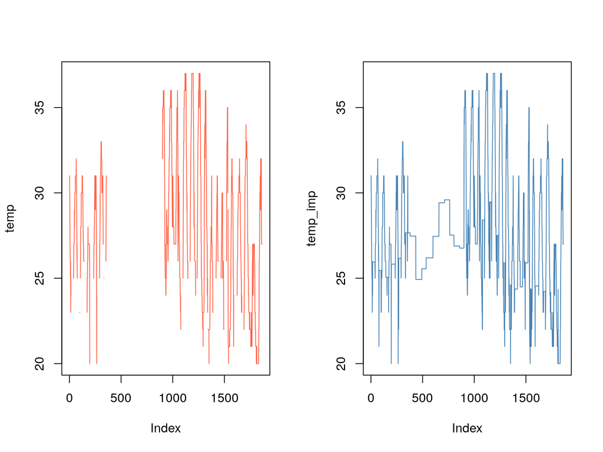

[output not shown]

```r
dat[USAFID == 720172][order(USAFID, year, month, day)][{
  op <- par(mfrow = c(1, 2))
  plot(temp, type = "l", col = "tomato")
  plot(temp_imp, type = "l", col = "steelblue")
  par(op)
}]
```

```r
dat[,
  list(
    wind.sp   = mean(wind.sp, na.rm = TRUE),
    temp      = mean(temp, na.rm = TRUE),
    atm.press = mean(atm.press, na.rm = TRUE)
  ), by = c("USAFID", "Date")
  ]

head(dat)
```

The previous is equivalent to write (compare both using the `identical()` function in R)

```r
dat_daily2 <- dat[
  ,
  .(
    wind.sp   = mean(wind.sp, na.rm = TRUE),
    temp      = mean(temp, na.rm = TRUE),
    atm.press = mean(atm.press, na.rm = TRUE)
  ),
  by = .(USAFID, Date)
]
```

When dealing with too many variables, we can use the `.SD` special symbol:

```r
# Listing the names
in_names  <- c("wind.sp", "temp", "atm.press")
out_names <- paste0(in_names, "_avg")

dat[,
  c(out_names) := lapply(.SD, mean, na.rm = TRUE),
  .SDcols = in_names,
  by      = c("USAFID", "Date")
  ]
```

## Other data.table goodies

- `shift()` Fast lead/lag for vectors and lists.
- `fifelse()` Fast if-else, similar to base R’s `ifelse()`.
- `fcoalesce()` Fast coalescing of missing values.
- `%between%` A short form of `(x < lb) & (x > up)`
- `%inrange%` A short form of `x %in% lb:up`
- `%chin%` Fast match of character vectors, equivalent to `x %in% X`, where both `x` and `X` are character vectors.
- `nafill()` Fill missing values using a constant, last observed value, or the next observed value.

## Scenarios

1. The 9, 99, 999, … coding for missigness.
2. The data contains dates
3. The data is a panel dataset with various measures per unit, and we need to create a lag
4. Need to create some summaries at the group level
5. Have two datasets and need to merge them by one or more keys/indices/ids.
6. Create a running mean spanning the last 7 observations.

## Benchmarks

- [H2O.ai](https://www.h2o.ai/)’s benchmark ([link](https://h2oai.github.io/db-benchmark/)): Designed by the lead developer of data.table [Matt Dowle](https://rdatatable.gitlab.io/data.table/)
- [RStudio’s](https://rstudio.com) benchmark ([link](https://cran.r-project.org/web/packages/vroom/vignettes/benchmarks.html)): Designed as part of the benchmarks with the vroom package.

```r
# Monthly average temperature plot
library(ggplot2)
library(akima)
dat_daily_plot <- with(
  dat_daily[mday(Date) == 1 & is.finite(temp_avg)],
  akima::interp(
    x = lon, y = lat, z = temp_avg
  )
)

image(dat_daily_plot)
```

```r
library(dtplyr)
library(dplyr)
data(diamonds, package="ggplot2")
dt_tibble <- lazy_dt(diamonds)
dt_dt     <- lazy_dt(as.data.table(diamonds))
dt        <- as.data.table(diamonds)
microbenchmark::microbenchmark(
  dplyr         = diamonds %>% group_by(carat) %>% summarise(mean(price), .groups="drop") %>% collect(),
  dtplyr_tibble = dt_tibble %>% group_by(carat) %>% summarise(mean(price)) %>% collect(),
  dtplyr_dt     = dt_dt %>% group_by(carat) %>% summarise(mean(price), .groups="drop") %>% collect(),
  data.table    = dt[, mean(price), by = carat]
)
```

```r
tmp <- tempfile(fileext="csv")
download.file(
  "https://raw.githubusercontent.com/Rdatatable/data.table/master/vignettes/flights14.csv",
  destfile = tmp,
  method   = "libcurl",
  timeout  = 1000
  )
dat_dt <- fread(tmp)
dat_tb <- as_tibble(dat_dt)
dat_lz <- lazy_dt(dat_tb)
```

```r
microbenchmark::microbenchmark(
  dplyr         = dat_tb %>% group_by(dest) %>% summarise(mean(air_time), .groups="drop") %>% collect(),
  dtplyr_tibble = dat_lz %>% group_by(dest) %>% summarise(mean(air_time), .groups="drop") %>% collect(),
  data.table    = dat_dt[, mean(air_time), by = dest], times = 100
)
```